# K-Nearest Neighbors

Starting off with the usual imports, these should be second nature by now!

```python
#For the dataframe and array manipulation
import pandas as pd
import numpy as np

#For visualization
import plotly
import plotly.express as px
```

We'll be starting with a basic example of how KNN works with an automatically generated dataset, so we'll also need the following imports.

```python
from sklearn.datasets import make_blobs
# from sklearn.neighbors
from sklearn.model_selection import train_test_split
from sklearn.metrics import accuracy_score
```

Sklearn's make_blobs() function is used to generate clustered data based on a variety of parameters; this is perfect for looking at how certain algorithms work.

We will also need the KNeighborsClassifier model for our classification task; note that we will need to import from `sklearn.neighbors`.

## Create and Visualize The Data

To start things off, we'll be creating a dataset with 400 total points clustered into two groups.

Using make_blobs(), we can also set the number of features each data point will have. We'll set the number of features to 2 so we can plot the features easily.

```python
points, labels = make_blobs(n_samples=400, centers=2, n_features=2,
                            cluster_std=.5, center_box=(0,8), random_state=42)
```

```python
# Look at the feature columns
```

```
array([[6.35909794, 4.50082194],
       [5.91609935, 5.04648729],
       [5.96146027, 4.74091132],
       [3.25384479, 9.5320802 ],
       [5.77694759, 4.57582734],
       [5.8651685 , 4.96305873],
       [5.05272837, 4.89099969],
       [3.03422323, 7.2671336 ],
       [3.36555424, 7.69139859],
       [3.10336782, 6.98284506]])
```

```python
# Look at the labels
```

```
array([1, 1, 1, 0, 1, 1, 1, 0, 0, 0])
```

We now already have the data split into X and y sets, which is perfect for the training step.

However, we may want to create a dataframe from these numpy arrays to be able to visualize what the data actually looks like.

```python
# Create the dataframe
```

```python
# Look at the DataFrame
```

|  | length | weight | target |
| --- | --- | --- | --- |
| 0 | 6.359098 | 4.500822 | 1 |
| 1 | 5.916099 | 5.046487 | 1 |
| 2 | 5.961460 | 4.740911 | 1 |
| 3 | 3.253845 | 9.532080 | 0 |
| 4 | 5.776948 | 4.575827 | 1 |
| 5 | 5.865169 | 4.963059 | 1 |
| 6 | 5.052728 | 4.891000 | 1 |
| 7 | 3.034223 | 7.267134 | 0 |
| 8 | 3.365554 | 7.691399 | 0 |
| 9 | 3.103368 | 6.982845 | 0 |

There are two species of fish: **red fish** and **blue fish**. A target of 0 represents a red fish and a target of 1 represents a blue fish. For each fish, we have its **length** and **weight**.

Now, lets create a scatter plot with each feature on a seperate axis.

Each point will have a color corresponding to its target value, the value that we want to predict.

```python
# px.scatter(data, x='length', y='weight',color='target',
```

[interactive chart not shown]

As can be seen in the plot, our data is nicely split into two distinct clusters. Because of this, we can make a pretty reasonable guess about the target value of a new point. Red fish tend to be a shorter and heavier, while blue fish are longer and lighter.

Let's train the model and see if it matches our intuition. Since we're only predicting a single point at a time, we'll train the model on the entire dataset.

## Fit and Predict

```python
# Break into X and y, create the classifier, and fit the model
```

Instead of doing train_test_split, we're going to select our own test points to get a better sense of the model.

Let's predict three distinct points and see what the model decides to output.

1. (6, 6.5)
2. (2, 6)
3. (4, 6)

```python
y_pred1 = clf.predict([[6,6.5]])
y_pred2 = clf.predict([[2,6]])
y_pred3 = clf.predict([[4,6]])
```

```python
import matplotlib.pyplot as plt

LABEL_COLOR_MAP = {0:'r',1:'b'}
label_color = [LABEL_COLOR_MAP[l] for l in labels]
```

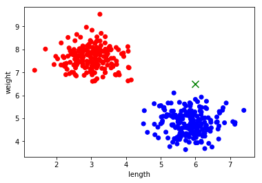

```python
plt.scatter(x=data['length'],y=data['weight'],c=label_color)
plt.xlabel('length')
plt.ylabel('weight')
plt.scatter(x=6,y=6.5,marker="x",c="g",s=100)
plt.show()
```

```python
# Take a look at pred_1
```

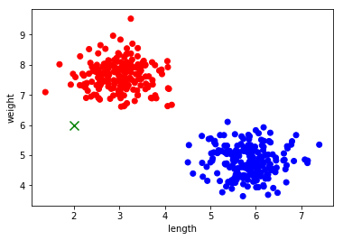

```python
plt.scatter(x=data['length'],y=data['weight'],c=label_color)
plt.xlabel('length')
plt.ylabel('weight')
plt.scatter(x=2,y=6,marker="x",c="g",s=100)
plt.show()
```

```python
# Take a look at pred2
```

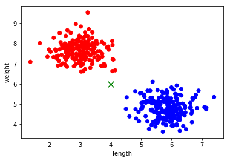

```python
plt.scatter(x=data['length'],y=data['weight'],c=label_color)
plt.xlabel('length')
plt.ylabel('weight')
plt.scatter(x=4,y=6,marker="x",c="g",s=100)
plt.show()
```

```python
# Take a look at pred_3
```

# KNN on Real World Data

We tested the algorithm on a small, artificial dataset with only 2 features, but how well does it perform on real world data with potentially many features?

We will be using a breast cancer dataset to hopefully find an answer to this question.

## Loading and Preprocessing the Data

```python
url = 'https://raw.githubusercontent.com/ishaandey/node/master/week-8/workshop/breast_cancer.csv'
df  = pd.read_csv(url)


df = df.drop(columns=['id','Unnamed: 32'])
df['diagnosis'] = df['diagnosis'].map({'M':1,'B':0})

# Break into X and y (the label is the 'diagnosis' column)



# X_train, X_test, y_train, y_test =
```

## Fitting the Model

```python
# Create and fit the KNN model
```

By default, the KNeighborsClassifier uses a value of K=5.

```python
# Predict on X_test and compare to y_test
```

```python
# Get the accuracy score for k=5
```

## What value of K?

While the default classifier was decent, we can also adjust the number of neighbors that the model looks at to get potentially better results.

```python
k_values = [1,5,10,50,200]
scores = []
```

```python
clf1 = KNeighborsClassifier(n_neighbors=1)
clf1.fit(X_train, y_train)
predicted = clf1.predict(X_test)
actual = np.array(y_test)
k1 = accuracy_score(predicted,actual)
scores.append(k1)
scores.append(k5)
print(k1)
```

```
0.9298245614035088
```

```python
# Try for n_neihbors = 10
```

```python
# Try for n_neihbors = 50
```

```python
# Try for n_neihbors = 200
```

```python
# Make sure to append each score to to scores list for this to work
plt.plot(k_values,scores,'go--', linewidth=2, markersize=12)
plt.xlabel('Number of Neighbors')
plt.ylabel('Accuracy of Model')
plt.title('K value versus Accuracy')
plt.show()
```

[output not shown]

As we can see, adding more neighbors does not equate to higher model accuracy. Each dataset is unique, and we need to select a value for K based on the nuances in the data to get the best performance from our KNN model.